# Eksploracja Masywnych Danych - projekt 1 - Analiza danych

# Rozmiar zbioru danych i podstawowe statystyki

```r
paste("Wczytane dane zawierają ", nrow(data), " rekordów oraz ", ncol(data), " kolumn.", sep=" ")
```

```
## [1] "Wczytane dane zawierają  52582  rekordów oraz  16  kolumn."
```

Podsumowanie wartości danych:

```r
summary(data)
```

```
##        X             length         cfin1             cfin2
##  Min.   :    0   Min.   :19.0   Min.   : 0.0000   Min.   : 0.0000
##  1st Qu.:13145   1st Qu.:24.0   1st Qu.: 0.0000   1st Qu.: 0.2778
##  Median :26291   Median :25.5   Median : 0.1111   Median : 0.7012
##  Mean   :26291   Mean   :25.3   Mean   : 0.4458   Mean   : 2.0248
##  3rd Qu.:39436   3rd Qu.:26.5   3rd Qu.: 0.3333   3rd Qu.: 1.7936
##  Max.   :52581   Max.   :32.5   Max.   :37.6667   Max.   :19.3958
##                                 NA's   :1581      NA's   :1536
##      chel1            chel2            lcop1              lcop2
##  Min.   : 0.000   Min.   : 5.238   Min.   :  0.3074   Min.   : 7.849
##  1st Qu.: 2.469   1st Qu.:13.427   1st Qu.:  2.5479   1st Qu.:17.808
##  Median : 5.750   Median :21.673   Median :  7.0000   Median :24.859
##  Mean   :10.006   Mean   :21.221   Mean   : 12.8108   Mean   :28.419
##  3rd Qu.:11.500   3rd Qu.:27.193   3rd Qu.: 21.2315   3rd Qu.:37.232
##  Max.   :75.000   Max.   :57.706   Max.   :115.5833   Max.   :68.736
##  NA's   :1555     NA's   :1556     NA's   :1653       NA's   :1591
##       fbar             recr              cumf             totaln
##  Min.   :0.0680   Min.   : 140515   Min.   :0.06833   Min.   : 144137
##  1st Qu.:0.2270   1st Qu.: 360061   1st Qu.:0.14809   1st Qu.: 306068
##  Median :0.3320   Median : 421391   Median :0.23191   Median : 539558
##  Mean   :0.3304   Mean   : 520367   Mean   :0.22981   Mean   : 514973
##  3rd Qu.:0.4560   3rd Qu.: 724151   3rd Qu.:0.29803   3rd Qu.: 730351
##  Max.   :0.8490   Max.   :1565890   Max.   :0.39801   Max.   :1015595
##
##       sst             sal            xmonth            nao
##  Min.   :12.77   Min.   :35.40   Min.   : 1.000   Min.   :-4.89000
##  1st Qu.:13.60   1st Qu.:35.51   1st Qu.: 5.000   1st Qu.:-1.89000
##  Median :13.86   Median :35.51   Median : 8.000   Median : 0.20000
##  Mean   :13.87   Mean   :35.51   Mean   : 7.258   Mean   :-0.09236
##  3rd Qu.:14.16   3rd Qu.:35.52   3rd Qu.: 9.000   3rd Qu.: 1.63000
##  Max.   :14.73   Max.   :35.61   Max.   :12.000   Max.   : 5.08000
##  NA's   :1584
```

Ilość brakujących danych dla poszczególnych kolumn:

```r
missingData <- sapply(data, function(x) sum(is.na(x)))
missingData
```

```
##      X length  cfin1  cfin2  chel1  chel2  lcop1  lcop2   fbar   recr
##      0      0   1581   1536   1555   1556   1653   1591      0      0
##   cumf totaln    sst    sal xmonth    nao
##      0      0   1584      0      0      0
```

Wykres ilości brakujących danych w zbiorze:

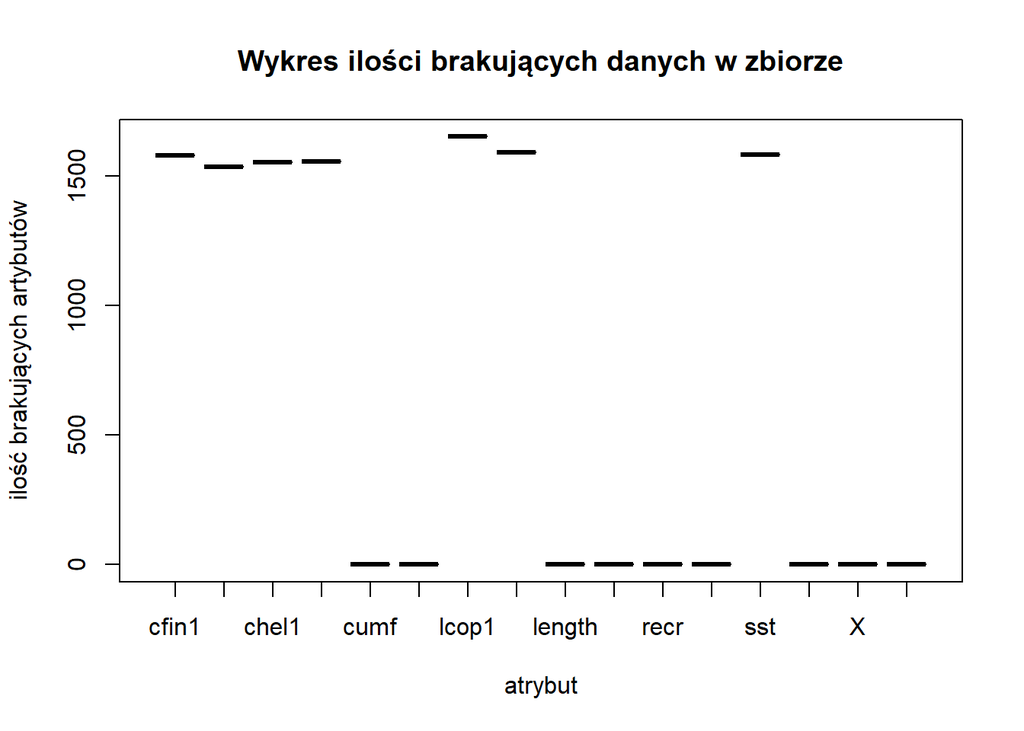

```r
plot(x = factor(names(missingData)), y = missingData, main="Wykres ilości brakujących danych w zbiorze", xlab="atrybut", ylab = "ilość brakujących artybutów")
```

Jak widać zbiór danych zawiera znaczną ilość brakujących danych, co może utrudnić ich późniejszą analizę.

# Brakujące dane

```r
library("imputeTS")
data$cfin1 <- na_kalman(data$cfin1)
data$cfin2 <- na_kalman(data$cfin2)
data$chel1 <- na_kalman(data$chel1)
data$chel2 <- na_kalman(data$chel2)
data$lcop1 <- na_kalman(data$lcop1)
data$lcop2 <- na_kalman(data$lcop2)
data$sst <- na_kalman(data$sst)
```

```r
missingData <- sapply(data, function(x) sum(is.na(x)))
missingData
```

```
##      X length  cfin1  cfin2  chel1  chel2  lcop1  lcop2   fbar   recr
##      0      0      0      0      0      0      0      0      0      0
##   cumf totaln    sst    sal xmonth    nao
##      0      0      0      0      0      0
```

# Szczegółowa analiza zbiorów wartości

Poniżej przedstawiono rozkłady wszystkich wartośi w zbiorze danych

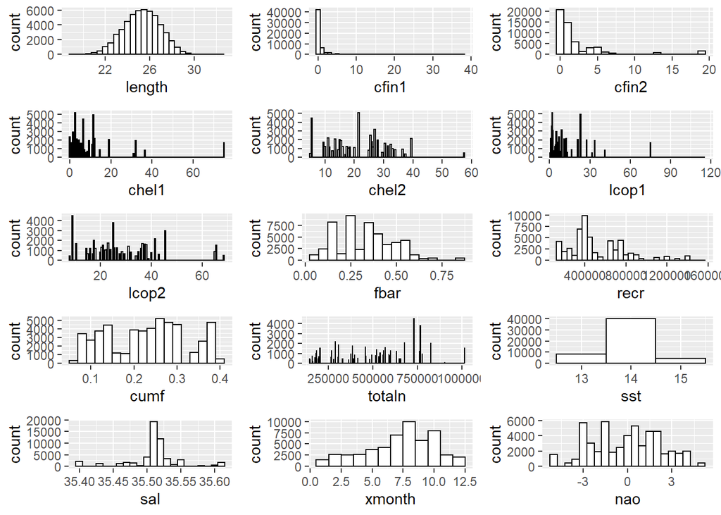

```r
library(ggplot2)
library(ggExtra)

lengthDissPlot <- ggplot(data, aes(x=length)) + geom_histogram(binwidth=.5, colour="black", fill="white")
cfin1DissPlot <- ggplot(data, aes(x=cfin1)) + geom_histogram(binwidth=1, colour="black", fill="white")
cfin2DissPlot <- ggplot(data, aes(x=cfin2)) + geom_histogram(binwidth=1, colour="black", fill="white")
chel1DissPlot <- ggplot(data, aes(x=chel1)) + geom_histogram(binwidth=.5, colour="black", fill="white")
chel2DissPlot <- ggplot(data, aes(x=chel2)) + geom_histogram(binwidth=.5, colour="black", fill="white")
lcop1DissPlot <- ggplot(data, aes(x=lcop1)) + geom_histogram(binwidth=.5, colour="black", fill="white")
lcop2DissPlot <- ggplot(data, aes(x=lcop2)) + geom_histogram(binwidth=.5, colour="black", fill="white")
fbarDissPlot <- ggplot(data, aes(x=fbar)) + geom_histogram(binwidth=.05, colour="black", fill="white")
recrDissPlot <- ggplot(data, aes(x=recr)) + geom_histogram(binwidth=50000.0, colour="black", fill="white")
cumfDissPlot <- ggplot(data, aes(x=cumf)) + geom_histogram(binwidth=.02, colour="black", fill="white")
totalnDissPlot <- ggplot(data, aes(x=totaln)) + geom_histogram(binwidth=1000.0, colour="black", fill="white")
sstDissPlot <- ggplot(data, aes(x=sst)) + geom_histogram(binwidth=1.0, colour="black", fill="white")
salDissPlot <- ggplot(data, aes(x=sal)) + geom_histogram(binwidth=.01, colour="black", fill="white")
xmonthDissPlot <- ggplot(data, aes(x=xmonth)) + geom_histogram(binwidth=1.0, colour="black", fill="white")
naoDissPlot <- ggplot(data, aes(x=nao)) + geom_histogram(binwidth=.5, colour="black", fill="white")


require(gridExtra)
grid.arrange(lengthDissPlot,cfin1DissPlot,cfin2DissPlot ,chel1DissPlot ,chel2DissPlot,lcop1DissPlot,lcop2DissPlot ,fbarDissPlot ,
recrDissPlot ,cumfDissPlot ,totalnDissPlot ,sstDissPlot ,salDissPlot ,xmonthDissPlot ,naoDissPlot, nrow = 5, ncol=3)
```

Z powyższych wykresów wynika, że jeśli chodzi o rozkład poszczególnych atrybutów to zbiór nie jest zrównoważony.

Analizując długość śledzia (*length*) można zauważyć, że ten atrybut przyjmuje rozkład zbliżony do rozkładu normalnego. W zbiorze danych znajduje się najwięcej śledzi o długości równej 25-26cm. Ze wcześniejszej analizy podsumowującej dane wynika także, że minimalna długość śledzia w zbiorze to 19cm, a maksymalna to 32.5cm. Średnia długość 25.3cm, a mediana to 25,5.

Jeśli chodzi o atrybut jakim jest dostępność planktonu (zarówno zagęszczenie *Calanus finmarchicus gat. 1* jak i *Calanus finmarchicus gat. 2*) to można zauważyć że w zbiorze znalazło się znacznie więcej danych z łowisk o mniejszej dostępności planktonu omawianego gatunku. Minimalna dostępność pierwszego gatunku tego planktonu to 0, maksymalna: ok 37,67. Srednia to ok. 0,45 a mediana to ok. 0,11. Jeśli chodzi o drugi gatunek planktonu *Calanus finmarchicus* to jego minimalne zagęszczenie wynosi 0, maksymalne - ok. 19,4, średnia to ok. 2,03 a mediana - 0.7.

# Korelacja między zmiennymi

W niniejszej sekcji została przeanalizowana korelacja między atrybutami.Na początek przedstawiono współczynniki korelacji wraz z graficzną macierzą korelacji.

Bardzo niski, jednak ujemny współczynnik korelacji (wynoszący -0.55) miedzy atrybutem *lcop1* a *neo* (oscylacja północnoatlantycka) świadczy o wysokiej, ale odwrotnej zaleznosci tych atrybutów. Może to być wyjaśnione z punktu widzenia przyrody przez to, że plankton może być przenoszony przez prądy morskie.

Niski ujemny współczynnik korelacji wskazujący na wysoką korelacje atrybutów można też zauważyć między *cumf* (łączne roczne natężenie połowów w regionie) a *totaln* (łączna liczba ryb złowionych w ramach połowu) - wynosi on -0.71, gdzie taka zależność też jest naturalna.

Jeśli chodzi o atrybut, którego będą dotyczyć badania w dalszej części pracy, czyli ługość śledzia, to jest najbardziej skorelowana z temperaturą przy powierzchni wody, a współczynnik tej korelacji wynosi -0.45 (czyli są to wartości odwrotnie zależne)

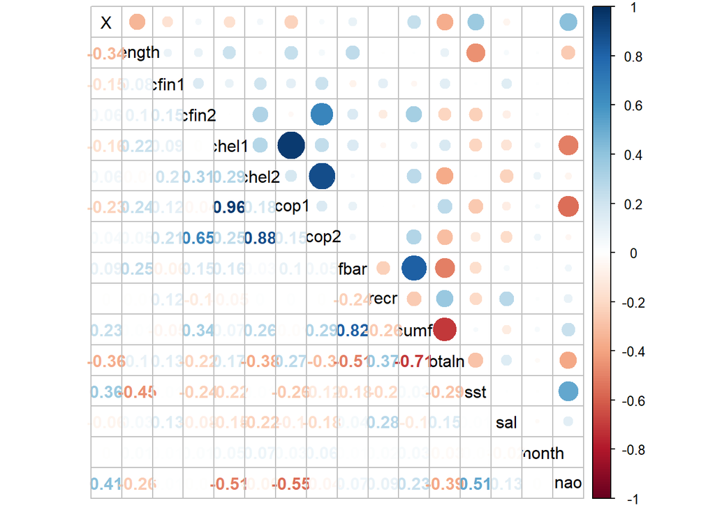

```r
res <- cor(data)
#round(res, 2)

library(corrplot)
corrplot.mixed(res, tl.col = "black", tl.srt = 45)
```

Żeby lepiej zwizualizować korelacje między omówionymi atrybutami przedstawiono wykresy zależności tych atrybutów.

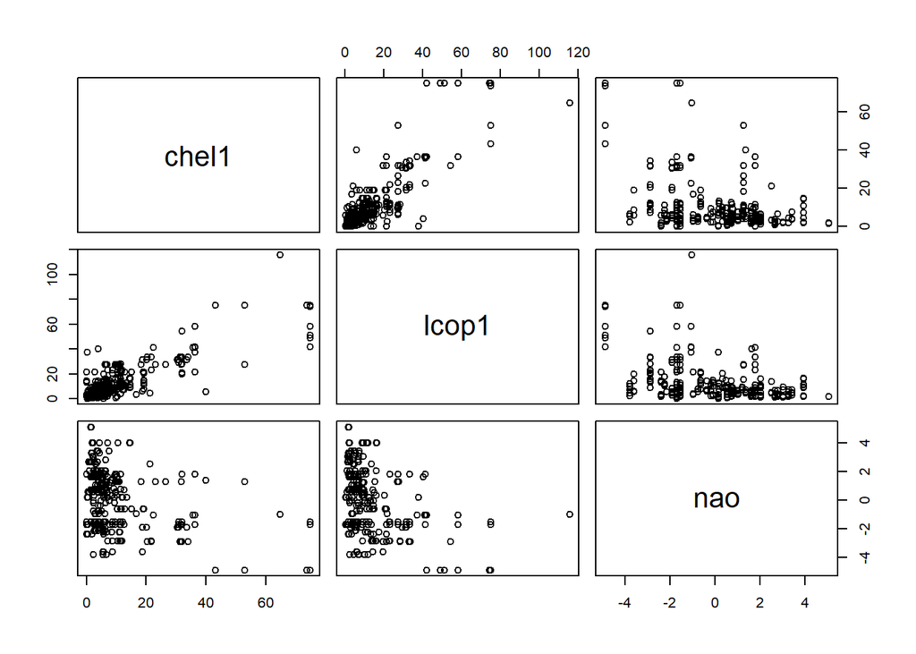

```r
plot(data[,c(5,7,16)])
```

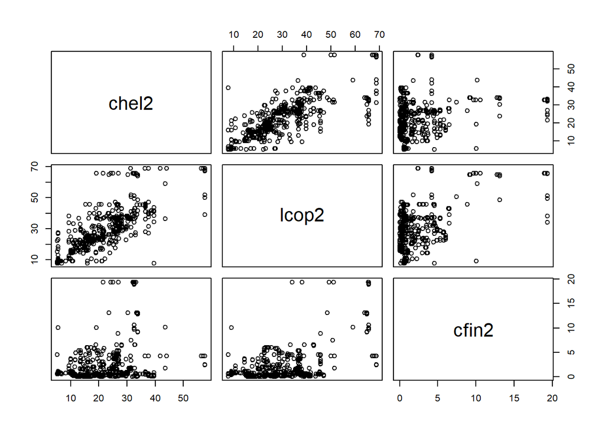

```r
plot(data[,c(6,8,4)])
```

Podobnie jak na poprzednim wykresie, i tu najbardziej widoczna jest korelacja między dostępnością dwóch z gatunków planktonu.

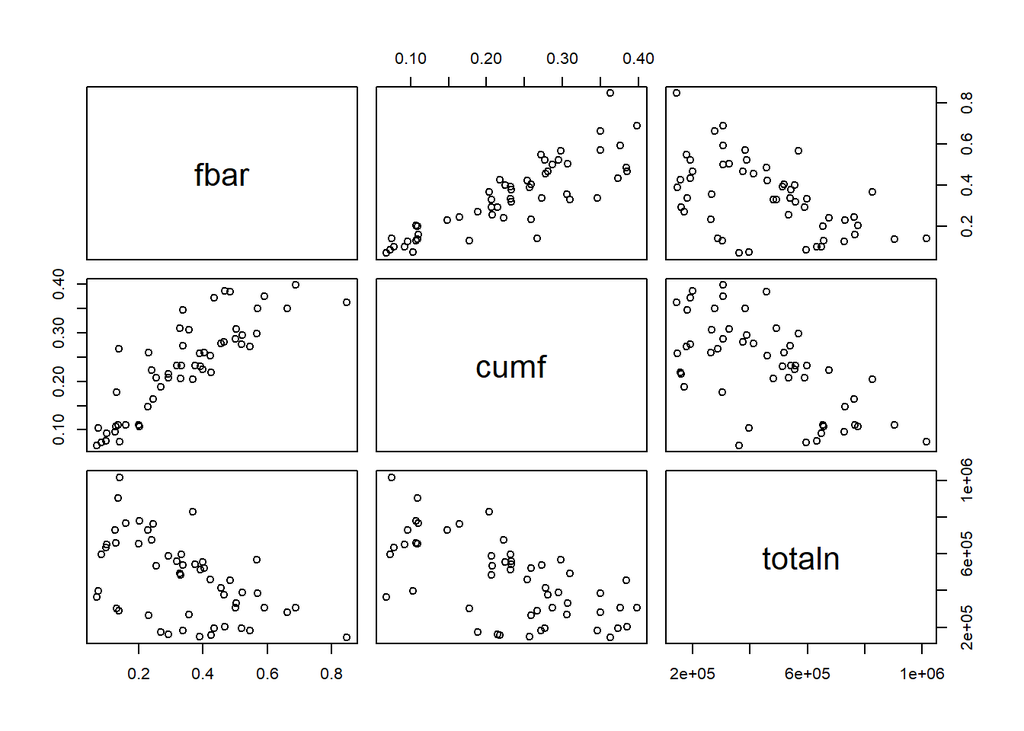

```r
plot(data[,c(9,11,12)])
```

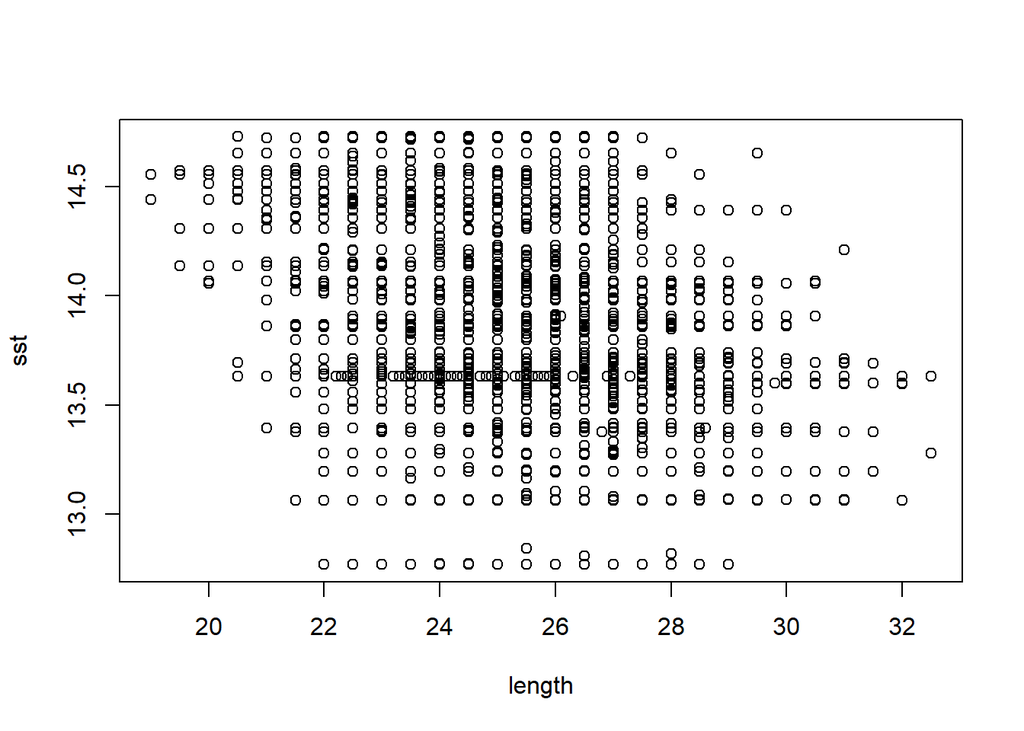

```r
plot(data[,c(2,13)])
```

# Zmiana rozmiaru śledzia w czasie

```r
library(ggplot2)
library(gganimate)
library(dplyr)
sampled <- sample_n(data,  round(nrow(data)*0.1))

p <- ggplot(
  sampled, aes(X, length, group = xmonth, color = factor(xmonth))) +
  geom_line() +
  scale_color_viridis_d() +
  labs(x = "Kolejne połowy", y = "Dlugosc sledzia") +
  theme(legend.position = "top")
```

[figure not shown]

```r
p + transition_reveal(X)
```

Z wykresu można zauważyć delikatny spadek śledzia w czasie. Choć na początku rozmiar śledzia znaczie rośnie, to po którkim czasie zaczyna już maleć.

# Przewidywanie rozmiaru śledzia

W niniejszym rozdziale postaramy się przewidzieć rozmiar śledzia z wykorzystaniem różnych metod uczenia maszynowego. W tym celu na początek dane zostaną podzielone na zbiór uczący (stanowiący 75% całego zbioru danych) i testowy (stanowiący 25% całego zbioru danych).

Parametry zostały domyślnie zoptymalizowane wybierając trzy wartości dla każdego zdefiniowanego dla modelu parametru optymalizacyjnego.

Do badań zostanie wykorzystana powtarzana ocena krzyżowa.

```r
library(caret)
```

```r
library(ggplot2)
library(gganimate)
library(dplyr)

inTraining <- createDataPartition(y = data$length, p = .75,list = FALSE)

training <- data[ inTraining, ]
testing  <- data[-inTraining, ]

ctrl <- trainControl( method = "repeatedcv", number = 5, repeats = 10)
```

Pierwszym z wykorzystanych algorytmów będzie Random Forest z liczbą drzew w lesie równą 10.

```r
fitRandomForestF <- train(length ~ ., data = training, method = "rf", importance=T, trControl = ctrl, ntree = 10) #rf
fitRandomForestF
```

```
## Random Forest
##
## 39438 samples
##    15 predictor
##
## No pre-processing
## Resampling: Cross-Validated (5 fold, repeated 10 times)
## Summary of sample sizes: 31549, 31550, 31550, 31552, 31551, 31552, ...
## Resampling results across tuning parameters:
##
##   mtry  RMSE      Rsquared   MAE
##    2    1.122600  0.5379404  0.8861271
##    8    1.111296  0.5521322  0.8722134
##   15    1.181804  0.5105627  0.9272984
##
## RMSE was used to select the optimal model using the smallest value.
## The final value used for the model was mtry = 8.
```

```r
rfClasses <- predict(fitRandomForestF, newdata = testing)
rfClasses <- sapply(rfClasses, round, digits = 0)

availableValues <- sapply(testing$length, round, digits = 0)
levels <- unique(c(availableValues, rfClasses))

confusionMatrix <- confusionMatrix(data = factor(rfClasses, levels = levels),   factor(availableValues, levels = levels))
confusionMatrix
```

```
## Confusion Matrix and Statistics
##
##           Reference
## Prediction   23   22   24   26   21   20   25   27   28   30   29   32
##         23  267  404  530   38   27   14   67    3    1    0    0    0
##         22   25   93   43    1   18   10    3    0    0    0    0    0
##         24  237  222  978  244    9    1  244   16   10    0    0    0
##         26   36    8  439 1772    0    0  439  384  391   10   10    1
##         21    0    7    1    0    3    2    0    0    0    0    0    0
##         20    0    0    0    0    0    0    0    0    0    0    0    0
##         25  102   50 1200 1302    3    0  615  131   76    2    3    1
##         27    5    1   82  799    0    0   91  372  726   12   28    2
##         28    0    1    8   99    0    0    5   72  260   25   38    0
##         30    0    0    0    0    0    0    0    0    0    0    0    0
##         29    0    0    1    4    0    0    0    4    9    2    3    0
##         32    0    0    0    0    0    0    0    0    0    0    0    0
##         31    0    0    0    0    0    0    0    0    0    0    0    0
##           Reference
## Prediction   31
##         23    0
##         22    0
##         24    0
##         26    0
##         21    0
##         20    0
##         25    0
##         27    1
##         28    1
##         30    0
##         29    0
##         32    0
##         31    0
##
## Overall Statistics
##
##                Accuracy : 0.3319
##                  95% CI : (0.3239, 0.3401)
##     No Information Rate : 0.324
##     P-Value [Acc > NIR] : 0.02705
##
```

[output cut: 18 more lines]

```
## Pos Pred Value             NaN   0.17647   0.17555   0.51081       NaN
## Neg Pred Value        0.997946   0.91210   0.94467   0.90400   0.99612
## Prevalence            0.002054   0.11138   0.07471   0.11207   0.00388
## Detection Rate        0.000000   0.04679   0.02830   0.01978   0.00000
## Detection Prevalence  0.000000   0.26514   0.16121   0.03872   0.00000
## Balanced Accuracy     0.500000   0.58718   0.61759   0.57759   0.50000
##                      Class: 29 Class: 32 Class: 31
## Sensitivity          0.0365854 0.0000000 0.0000000
## Specificity          0.9984688 1.0000000 1.0000000
## Pos Pred Value       0.1304348       NaN       NaN
## Neg Pred Value       0.9939791 0.9996957 0.9998478
## Prevalence           0.0062386 0.0003043 0.0001522
## Detection Rate       0.0002282 0.0000000 0.0000000
## Detection Prevalence 0.0017498 0.0000000 0.0000000
## Balanced Accuracy    0.5175271 0.5000000 0.5000000
```

```r
confusionMatrix$overall
```

```
##       Accuracy          Kappa  AccuracyLower  AccuracyUpper   AccuracyNull
##     0.33193853     0.18988195     0.32388795     0.34006358     0.32402617
## AccuracyPValue  McnemarPValue
##     0.02705031            NaN
```

Kolejnym przebadanym regresorem będzie regresja liniowa

```r
fitLR <- train(length ~ ., data = training, method = "lm", importance=T, trControl = ctrl)
fitLR
```

```
## Linear Regression
##
## 39438 samples
##    15 predictor
##
## No pre-processing
## Resampling: Cross-Validated (5 fold, repeated 10 times)
## Summary of sample sizes: 31551, 31550, 31551, 31549, 31551, 31552, ...
## Resampling results:
##
##   RMSE      Rsquared   MAE
##   1.327042  0.3539804  1.046856
##
## Tuning parameter 'intercept' was held constant at a value of TRUE
```

```r
lrClasses <- predict(fitLR, newdata = testing)
lrClasses <- sapply(lrClasses, round, digits = 0)

availableValues <- sapply(testing$length, round, digits = 0)
levels <- unique(c(availableValues, lrClasses))

confusionMatrix <- confusionMatrix(data = factor(lrClasses, levels = levels),   factor(availableValues, levels = levels))
confusionMatrix
```

```
## Confusion Matrix and Statistics
##
##           Reference
## Prediction   23   22   24   26   21   20   25   27   28   30   29   32
##         23  134  208  268   38    7    1   42    2    0    0    0    0
##         22    0    0    0    0    0    0    0    0    0    0    0    0
##         24  251  284  791  240   19    9  211   12    2    0    0    0
##         26   38   20  637 1922    0    0  437  493  870   24   45    2
##         21    0    0    0    0    0    0    0    0    0    0    0    0
##         20    0    0    0    0    0    0    0    0    0    0    0    0
##         25  246  272 1545 1715   34   17  744  284  208    7    7    0
##         27    3    1   30  304    0    0   20  173  347   19   27    1
##         28    0    1   11   39    0    0   10   18   46    1    3    1
##         30    0    0    0    1    0    0    0    0    0    0    0    0
##         29    0    0    0    0    0    0    0    0    0    0    0    0
##         32    0    0    0    0    0    0    0    0    0    0    0    0
##         31    0    0    0    0    0    0    0    0    0    0    0    0
##           Reference
## Prediction   31
##         23    0
##         22    0
##         24    0
##         26    1
##         21    0
##         20    0
##         25    0
##         27    0
##         28    1
##         30    0
##         29    0
##         32    0
##         31    0
##
## Overall Statistics
##
##                Accuracy : 0.2899
##                  95% CI : (0.2821, 0.2977)
##     No Information Rate : 0.324
##     P-Value [Acc > NIR] : 1
##
```

[output cut: 18 more lines]

```
## Pos Pred Value             NaN    0.1465   0.18703  0.351145 0.000e+00
## Neg Pred Value        0.997946    0.9107   0.93379  0.890340 9.961e-01
## Prevalence            0.002054    0.1114   0.07471  0.112066 3.880e-03
## Detection Rate        0.000000    0.0566   0.01316  0.003500 0.000e+00
## Detection Prevalence  0.000000    0.3864   0.07037  0.009967 7.608e-05
## Balanced Accuracy     0.500000    0.5685   0.55717  0.511973 5.000e-01
##                      Class: 29 Class: 32 Class: 31
## Sensitivity           0.000000 0.0000000 0.0000000
## Specificity           1.000000 1.0000000 1.0000000
## Pos Pred Value             NaN       NaN       NaN
## Neg Pred Value        0.993761 0.9996957 0.9998478
## Prevalence            0.006239 0.0003043 0.0001522
## Detection Rate        0.000000 0.0000000 0.0000000
## Detection Prevalence  0.000000 0.0000000 0.0000000
## Balanced Accuracy     0.500000 0.5000000 0.5000000
```

```r
confusionMatrix$overall
```

```
##       Accuracy          Kappa  AccuracyLower  AccuracyUpper   AccuracyNull
##      0.2898661      0.1152575      0.2821190      0.2977063      0.3240262
## AccuracyPValue  McnemarPValue
##      1.0000000            NaN
```

Ostatnim z przebadanych algorytmów został kNN

```r
fitKNN <- train(length ~ ., data = training, method = "knn", importance=T, trControl = ctrl)
fitKNN
```

```
## k-Nearest Neighbors
##
## 39438 samples
##    15 predictor
##
## No pre-processing
## Resampling: Cross-Validated (5 fold, repeated 10 times)
## Summary of sample sizes: 31551, 31552, 31549, 31550, 31550, 31551, ...
## Resampling results across tuning parameters:
##
##   k  RMSE      Rsquared   MAE
##   5  1.123669  0.5447638  0.8812479
##   7  1.107900  0.5540048  0.8701258
##   9  1.100991  0.5579812  0.8652422
##
## RMSE was used to select the optimal model using the smallest value.
## The final value used for the model was k = 9.
```

```r
knnClasses <- predict(fitKNN, newdata = testing)
knnClasses <- sapply(knnClasses, round, digits = 0)

availableValues <- sapply(testing$length, round, digits = 0)
levels <- unique(c(availableValues, knnClasses))

confusionMatrix <- confusionMatrix(data = factor(knnClasses, levels = levels),   factor(availableValues, levels = levels))
confusionMatrix
```

```
## Confusion Matrix and Statistics
##
##           Reference
## Prediction   23   22   24   26   21   20   25   27   28   30   29   32
##         23  257  386  495   33   26   13   47    3    0    0    0    0
##         22   32  108   38    1   21   10    4    0    0    0    0    0
##         24  253  224 1050  269   11    2  274    9   13    0    0    0
##         26   33    7  469 1888    1    0  467  430  410    9   11    0
##         21    1    4    0    0    0    1    0    0    0    0    0    0
##         20    0    0    0    0    0    0    0    0    0    0    0    0
##         25   92   56 1153 1204    1    1  595  125   64    3    2    1
##         27    4    1   69  777    0    0   70  341  694   10   31    2
##         28    0    0    7   86    0    0    7   74  288   28   37    1
##         30    0    0    0    0    0    0    0    0    0    0    0    0
##         29    0    0    1    1    0    0    0    0    4    1    1    0
##         32    0    0    0    0    0    0    0    0    0    0    0    0
##         31    0    0    0    0    0    0    0    0    0    0    0    0
##           Reference
## Prediction   31
##         23    0
##         22    0
##         24    0
##         26    0
##         21    0
##         20    0
##         25    0
##         27    1
##         28    1
##         30    0
##         29    0
##         32    0
##         31    0
##
## Overall Statistics
##
##                Accuracy : 0.3445
##                  95% CI : (0.3364, 0.3527)
##     No Information Rate : 0.324
##     P-Value [Acc > NIR] : 3.197e-07
##
```

[output cut: 18 more lines]

```
## Pos Pred Value             NaN   0.18047   0.17050   0.54442       NaN
## Neg Pred Value        0.997946   0.91175   0.94248   0.90606   0.99612
## Prevalence            0.002054   0.11138   0.07471   0.11207   0.00388
## Detection Rate        0.000000   0.04527   0.02594   0.02191   0.00000
## Detection Prevalence  0.000000   0.25084   0.15216   0.04025   0.00000
## Balanced Accuracy     0.500000   0.58754   0.60542   0.58743   0.50000
##                      Class: 29 Class: 32 Class: 31
## Sensitivity          1.220e-02 0.0000000 0.0000000
## Specificity          9.995e-01 1.0000000 1.0000000
## Pos Pred Value       1.250e-01       NaN       NaN
## Neg Pred Value       9.938e-01 0.9996957 0.9998478
## Prevalence           6.239e-03 0.0003043 0.0001522
## Detection Rate       7.608e-05 0.0000000 0.0000000
## Detection Prevalence 6.086e-04 0.0000000 0.0000000
## Balanced Accuracy    5.058e-01 0.5000000 0.5000000
```

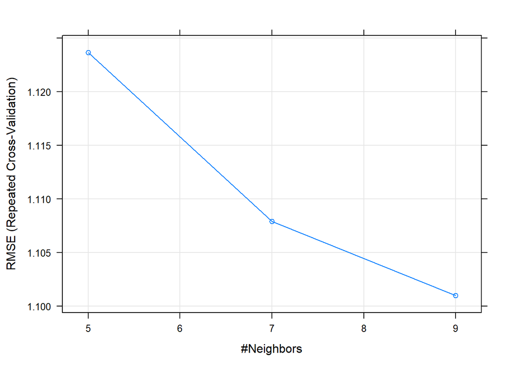

```r
plot(fitKNN)
```

```r
confusionMatrix$overall
```

```
##       Accuracy          Kappa  AccuracyLower  AccuracyUpper   AccuracyNull
##   3.444918e-01   1.991203e-01   3.363650e-01   3.526874e-01   3.240262e-01
## AccuracyPValue  McnemarPValue
##   3.197132e-07            NaN
```

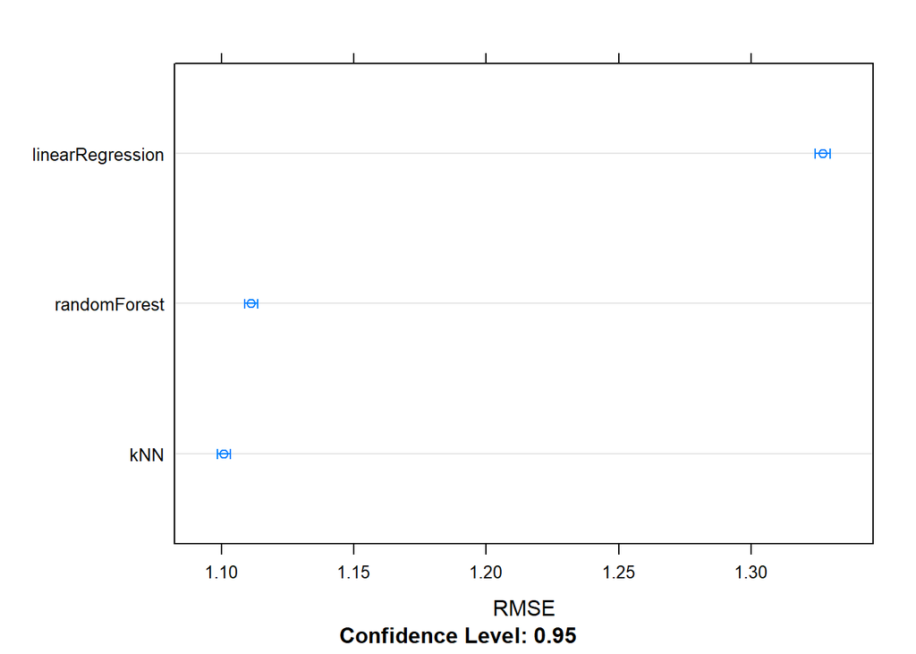

```r
x <- list(randomForest = fitRandomForestF, linearRegression = fitLR, kNN = fitKNN) %>% resamples()

dotplot(x, metric = "RMSE")
```

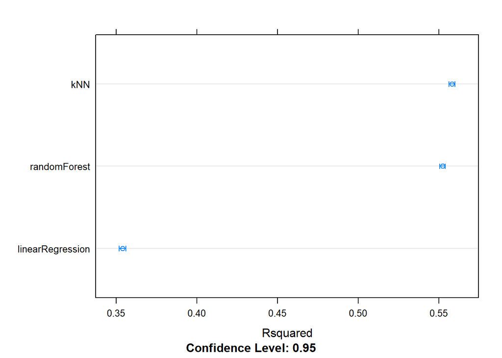

```r
dotplot(x, metric = "Rsquared")
```

# Analiza ważnośći atrybutów najlepszego znalezionego modelu regresji

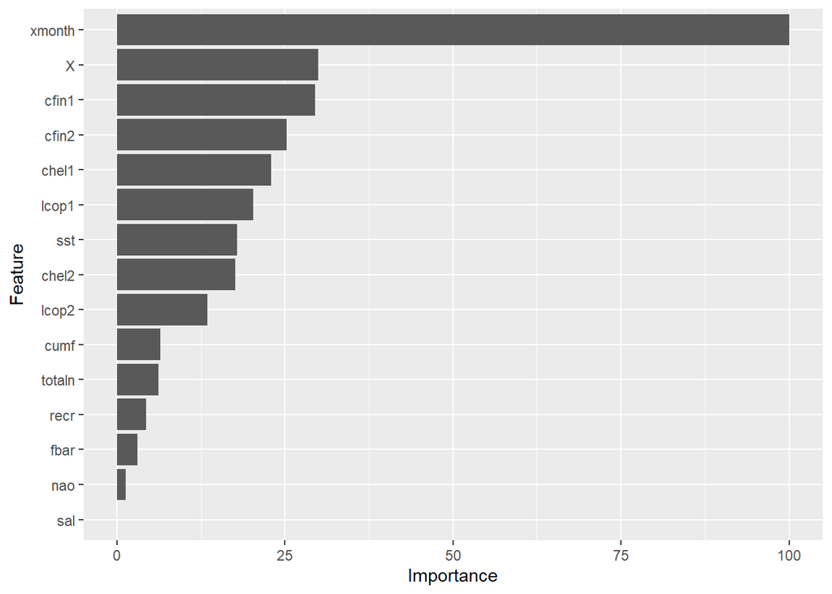

```r
ggplot(varImp(fitRandomForestF))
```

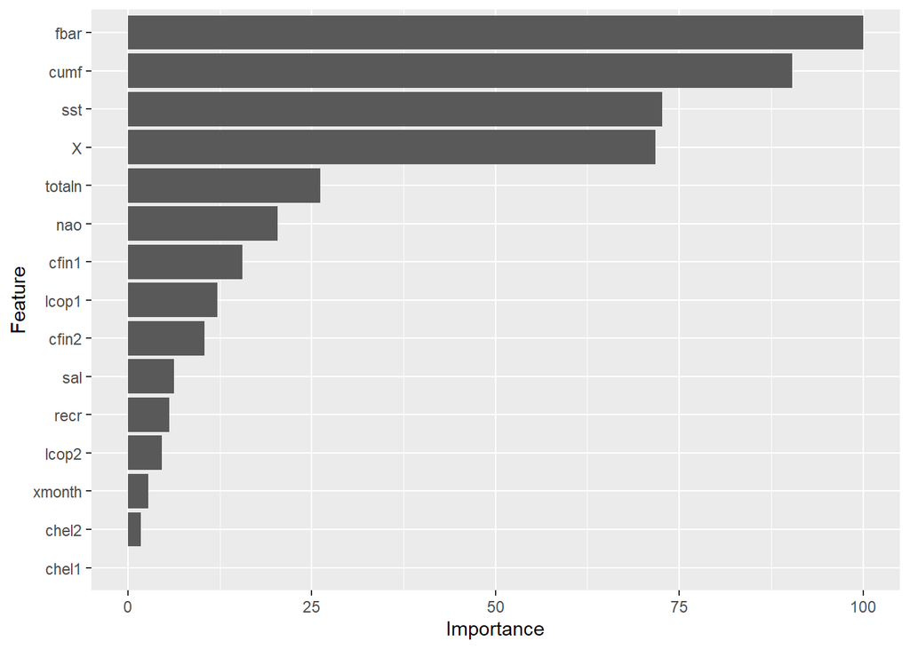

```r
ggplot(varImp(fitLR))
```

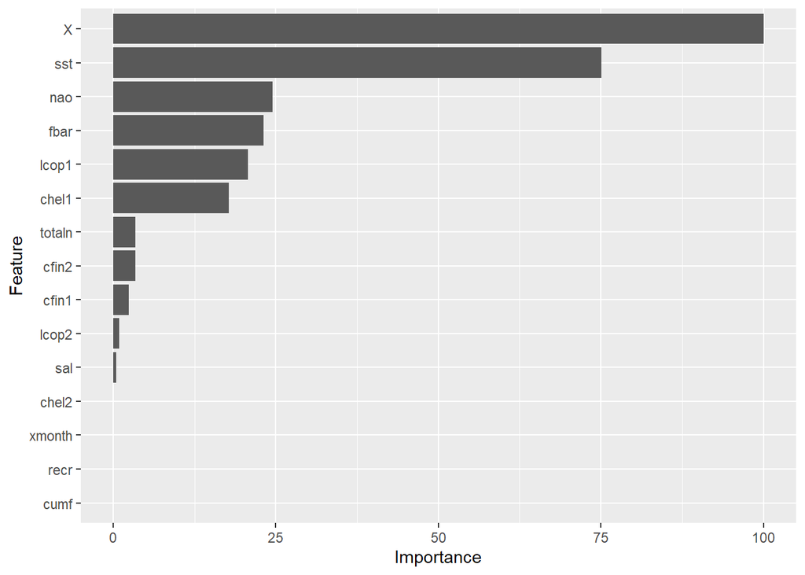

```r
ggplot(varImp(fitKNN))
```